# 5003 Homework 2

Author： LAN Tianwei 藍天蔚  
ID： 21230969  
Email： tlanaa@connect.ust.hk

## (a) Random displacement distribution without external potential

Given Continuous-time Langevin equation: $$ \gamma\frac{dx}{dt}= -\frac{dU}{dx} + \zeta(t), \quad \langle\zeta(t)\zeta(t')\rangle= 2\gamma k_B T\delta(t-t'). \tag{1} $$ where $U(x)=0$, therefore: $$ \frac{dx}{dt}= \frac{1}{\gamma}\zeta(t) \tag{2} $$ Let $t_n = nΔt$, define $$ \eta_n= \int_{t_n}^{t_n+\Delta t}\zeta(t)dt \tag{3} $$ as random impulse at the $n$ step. Since $\zeta$ is Guassian distributed white noise: $$ \langle\eta_n\rangle= 0 , \langle\eta_n\eta_m\rangle= 2\gamma k_B T\Delta t\,\delta_{nm}. \tag{4} $$ So the random impulse of each step is also Guassian distributed: $$ \eta_n\sim \mathcal{N}(0,2\gamma k_B T Δt) \tag{5} $$ Therefore we can derive the displacement per step according to the integration of formula $(2)$: $$ x_{n+1}-x_n= \frac{1}{\gamma}\eta_n \;\Longrightarrow\; \Delta x_{\text{rand}}\sim\mathcal{N}\!\left(0,\,\frac{2k_B T}{\gamma}\Delta t\right). \tag{6} $$ set $\gamma=1,\;k_B T=1$ as mentioned (which means $D=1$): $$ \sigma^2= 2\Delta t \quad\Longrightarrow\quad \Delta x_{\text{rand}}= \sqrt{2\Delta t}\;\mathcal{N}(0,1). \tag{7} $$ which suggests how to implement stepwise shifting in the code.

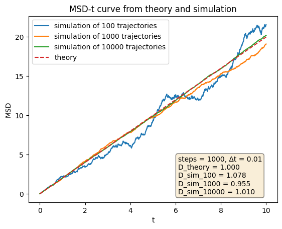

```python
# (a) Brownian Motion Simulation at U(x)=0
import numpy as np
import matplotlib.pyplot as plt

def BMS(steps = 1000, delta_t = 0.01, n_traj = 1000, kbt = 1, gamma = 1):
    sigma = np.sqrt(2*kbt*delta_t/gamma)
    random_steps = np.random.normal(0, sigma, size=(n_traj, steps))
    X = np.zeros((n_traj, steps + 1))
    X[:, 1:] = np.cumsum(random_steps, axis=1)
    return X

def MSD(X,x_0 = 0):
    return np.mean((X-x_0)**2, axis=0)

if __name__ == "__main__":
    steps = 1000
    delta_t = 0.01
    X1 = BMS(steps, delta_t, 100)
    X2 = BMS(steps, delta_t, 1000)
    X3 = BMS(steps, delta_t, 10000)
    msd_1 = MSD(X1)
    msd_2 = MSD(X2)
    msd_3 = MSD(X3)

    t = np.arange(steps + 1) * delta_t
    msd_theory = 2 * t                        # D = 2*kbt/gamma = 1

    plt.title("MSD-t curve from theory and simulation")
    plt.plot(t, msd_1, label="simulation of 100 trajectories")
    plt.plot(t, msd_2, label="simulation of 1000 trajectories")
    plt.plot(t, msd_3, label="simulation of 10000 trajectories")
    plt.plot(t, msd_theory, "--", label="theory")
    D_sim_1 = msd_1[-1] / (2 * t[-1])
    D_sim_2 = msd_2[-1] / (2 * t[-1])
    D_sim_3 = msd_3[-1] / (2 * t[-1])
    info = (f"steps = {steps}, Δt = {delta_t}\n"
            "D_theory = 1.000\n"
        f"D_sim_100 = {D_sim_1:.3f}\n"
        f"D_sim_1000 = {D_sim_2:.3f}\n"
        f"D_sim_10000 = {D_sim_3:.3f}")
    plt.text(0.6, 0.25, info,
         transform=plt.gca().transAxes,
         verticalalignment='top',
         bbox=dict(boxstyle='round', facecolor='wheat', alpha=0.5))
    plt.xlabel("t"); plt.ylabel("MSD"); plt.legend(); plt.show()
```

The simulation results show that the more trajectories there are, the closer the MSD simulation value is to the theoretical value.

## (b) Random displacement distribution with confinement potential

Given Continuous-time overdamped Langevin equation: $$ \gamma\frac{dx}{dt}= -\frac{dU}{dx} + \zeta(t), \quad \langle\zeta(t)\zeta(t')\rangle= 2\gamma k_B T\delta(t-t'). \tag{1} $$ where $U(x)= x^2/2 $, therefore the equation changes into: $$ \gamma\frac{dx}{dt}= -x + \zeta(t), \quad \langle\zeta(t)\zeta(t')\rangle= 2\gamma k_B T\delta(t-t'). \tag{2} $$ Solve as 1st-order ODE: $$ x(t)=x(0)e^{-t/\gamma}+\frac{1}{\gamma}\int_{0}^{t}e^{-(t-s)/\gamma} \zeta(s)ds \tag{3} $$ When $t\rightarrow \infty$: $$ x_\infty = \frac{1}{\gamma}\int_{0}^{\infty}e^{-s/\gamma}\zeta(s)ds \tag{4} $$ which is a linear superposition of Gaussian noise, so $x_\infty$ as a random variable has Gaussianity.
The mean and variance of $x(t)$ are calculated as follow: $$ \langle\zeta\rangle=0 \quad\Longrightarrow\quad \langle x(t)\rangle = x(0)e^{-t/\gamma} \tag{5} $$ $$ Var[x(t)]=\frac{1}{\gamma^2}\int_{0}^{t}\int_{0}^{t}e^{-(t-s)/\gamma}e^{-(t-s')/\gamma}\langle\zeta(t)\zeta(t')\rangle dsds'=k_B T(1-e^{-2t/\gamma}) \tag{6} $$ The stationary PDF of $x_\infty$ is as follow (when $t\rightarrow \infty$): $$ \langle x_\infty \rangle=0,Var[x_\infty]=k_B T \Longrightarrow f(x)=\frac{1}{\sqrt{2\pi k_B T}}e^{-x^2/(2 k_B T)} \tag{7} $$ for $k_B T=1 , x_\infty\sim\mathcal{N}(0,1)$ $$ f(x)=\frac{1}{\sqrt{2\pi}}e^{-x^2/2} \tag{8} $$ Therefore, under the given conditions, the theoretical distribution of $x_\infty$ is the standard normal distribution.
To simulate this in the code, the SDE is discretized as: $$ x_{n+1}=x_n-x_n Δt+\sqrt{2Δt}\mathcal{N}(0,1) \tag{9} $$

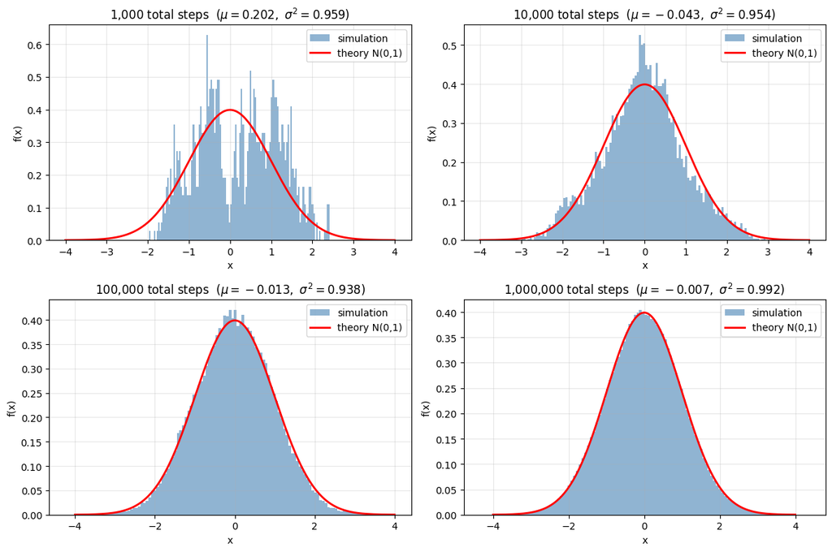

```python
# (b) Confined Brownian Motion Simulation at U(x)=x²/2

import numpy as np
import matplotlib.pyplot as plt

def confined_BMS(steps=1000, delta_t=0.01, x0=0.0):
    sigma = np.sqrt(2 * delta_t)
    rand = np.random.normal(0, sigma, size=steps)
    X = np.empty(steps + 1)
    X[0] = x0
    for n in range(steps):
        X[n+1] = X[n] - X[n] * delta_t + rand[n]
    return X

step_list   = [1_000, 10_000, 100_000, 1_000_000]
delta_t     = 0.01
pdf_x       = np.linspace(-4, 4, 400)
pdf_y       = np.exp(-pdf_x**2/2) / np.sqrt(2*np.pi)
fig, axes = plt.subplots(2, 2, figsize=(12, 8))
axes = axes.ravel()

for ax, st in zip(axes, step_list):
    X = confined_BMS(steps=st, delta_t=delta_t)

    ax.hist(X, bins=120, density=True,
            alpha=0.6, color='steelblue', label='simulation')
    ax.plot(pdf_x, pdf_y, 'r-', lw=2, label='theory N(0,1)')

    mu, var = X.mean(), X.var()
    ax.set_title(f'{st:,} total steps  '
                 f'$(\\mu={mu:.3f},\\ \\sigma^2={var:.3f})$')
    ax.set_xlabel('x'); ax.set_ylabel('f(x)')
    ax.legend(); ax.grid(alpha=0.3)

plt.tight_layout()
plt.show()
```

As the number of steps increases (that is, the time becomes longer), the PDF of $x$ approaches the standard normal distribution.